# Aligning a french audiobook 2

In this notebook we will align an audio book using Praat or Audacity for pre-segmenation and the MFA for forced alignment.

First, download the SIWIS_audiobook.zip from Google drive in the Sessino 2 folder. We see there is an audio file and the corresponding text. Use now either Praat or Audacity workflow for a pre-segmenation and annotation as outlined in Audacity_PRAAT_useful_functions.

I will show here the workflow for Praat as an example. Here I used mostly the standard settings for the detection of voiced regions, but the threshold was set to -30 dB.

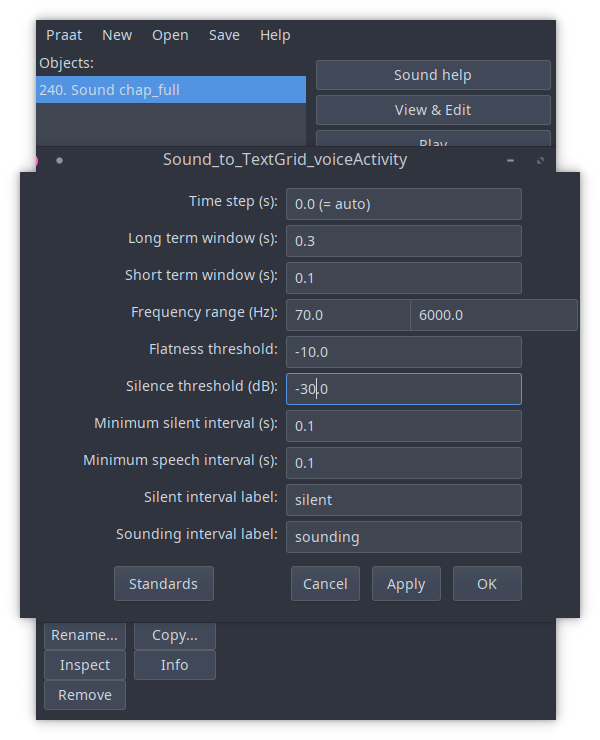

In this example, I entered the text of the first couple of sentences:

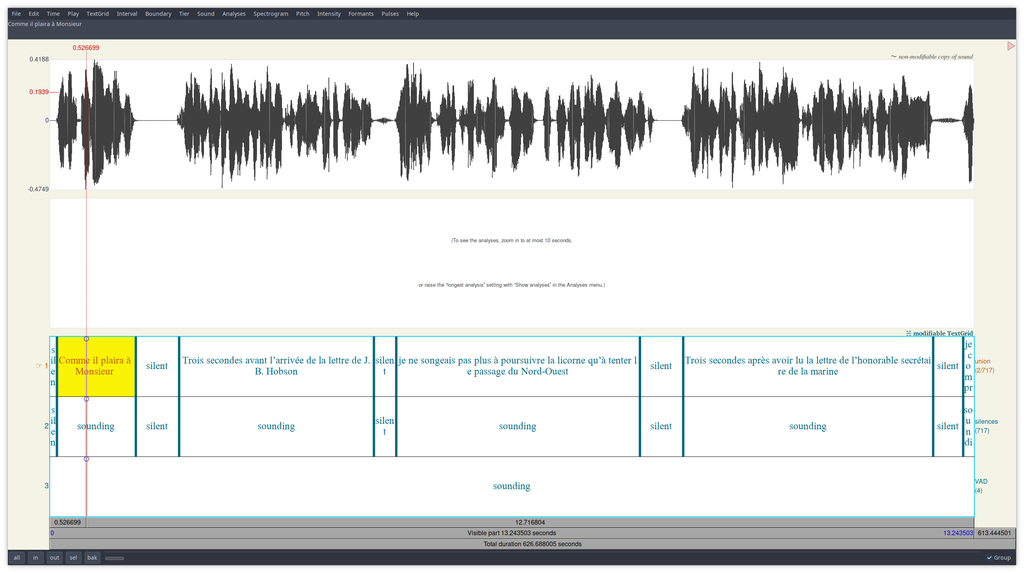

Then I run the MFA_corpus_preparation Praat script and extract all files in a folder "mfa_ready".

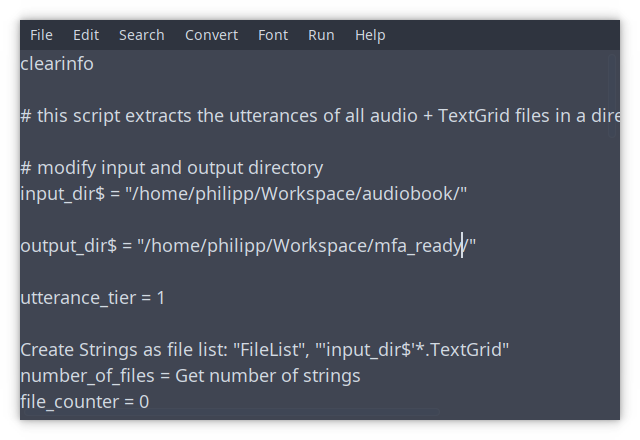

In this case, 16 utterances were extracted. The MFA can then be used for the alignment:

```python
! mfa align ~/Workspace/mfa_ready/ french_mfa french_mfa ~/Workspace/audiobook_alignments/
```

[output not shown]

[output cut: 24 more lines]

[output not shown]

Alignments are created for each utterance. They can be found in the audiobook_alignments folder.

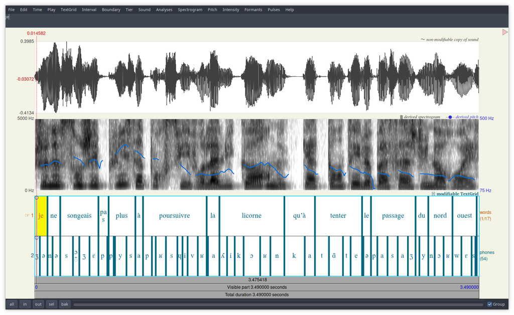